# Multivariate analysis Final Report

```r
# Plotting eigenvalues and % of variance for each axis
(ev2 <- spe.ca$CA$eig)
```

```
##         CA1         CA2         CA3         CA4         CA5         CA6
## 0.200387230 0.168551964 0.152814236 0.134920172 0.129386022 0.110315095
##         CA7         CA8         CA9        CA10        CA11        CA12
## 0.102907395 0.096691643 0.094487742 0.090226826 0.084203665 0.079682599
##        CA13        CA14        CA15        CA16        CA17        CA18
## 0.077208389 0.076028334 0.074038437 0.071251625 0.069535972 0.064570546
##        CA19        CA20        CA21        CA22        CA23        CA24
## 0.063851820 0.059879267 0.058354287 0.054775478 0.054076527 0.051144925
##        CA25        CA26        CA27        CA28        CA29        CA30
## 0.050994809 0.049404188 0.047724064 0.046971576 0.044069782 0.043105035
##        CA31        CA32        CA33        CA34        CA35        CA36
## 0.039115441 0.038282709 0.037190225 0.035832447 0.033730206 0.032848034
##        CA37        CA38        CA39        CA40        CA41        CA42
## 0.031379347 0.029210011 0.027749433 0.026213089 0.024907212 0.023643752
##        CA43        CA44        CA45        CA46        CA47        CA48
## 0.023037356 0.021955052 0.020893355 0.017938813 0.015954556 0.013156821
##        CA49
## 0.009848182
```

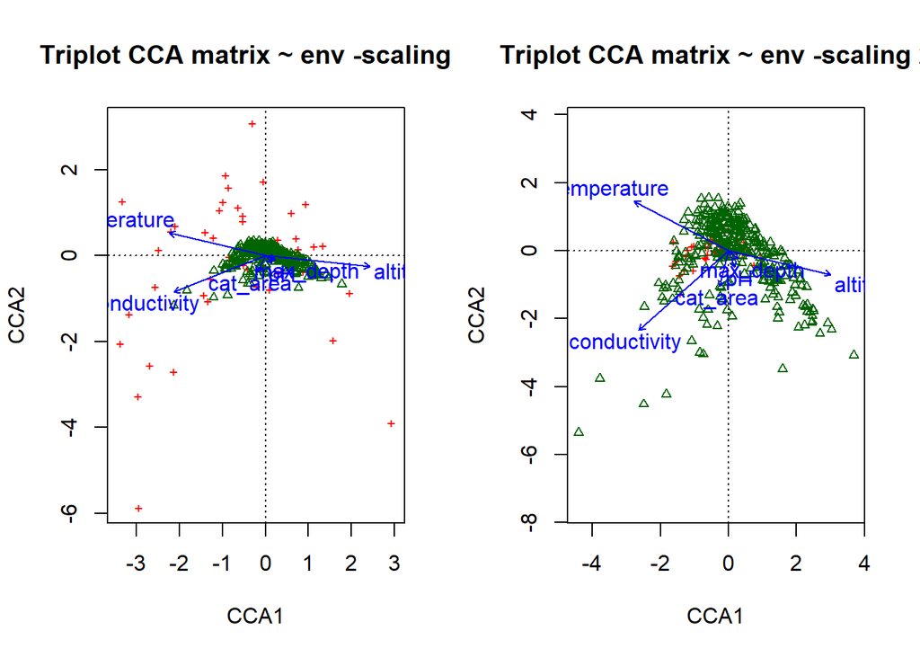

```r
# CA biplots
par(mfrow=c(1,2))
plot(spe.ca, scaling=1, display=c('sp', 'lc', 'cn'), main='Triplot CCA matrix ~ env -scaling 1')
plot(spe.ca, display=c('sp', 'lc', 'cn'), main="Triplot CCA matrix ~ env -scaling 2")
```

```r
#conductivity, temperature and altitude most influential

# A posteriori projection of environmental variables in a CA
(spe.ca.env <- envfit(spe.ca, env))
```

```
##
## ***VECTORS
##
##                  CCA1     CCA2     r2 Pr(>r)
## cat_area     -0.42322 -0.90603 0.0327  0.009 **
## altitude      0.99313 -0.11706 0.4700  0.001 ***
## max_depth     0.90732 -0.42044 0.0057  0.365
## conductivity -0.90405 -0.42743 0.5050  0.001 ***
## pH            0.56958 -0.82194 0.0079  0.228
## temperature  -0.96475  0.26316 0.4440  0.001 ***
## ---
## Signif. codes:  0 '***' 0.001 '**' 0.01 '*' 0.05 '.' 0.1 ' ' 1
## Permutation: free
## Number of permutations: 999
```

Multivariate analysis using gllvm package: We considered binomial approach as response variable in macroinvertebrates data is binary. Distribution was estimated using variational approximation method (method = “VA”), link function probit.

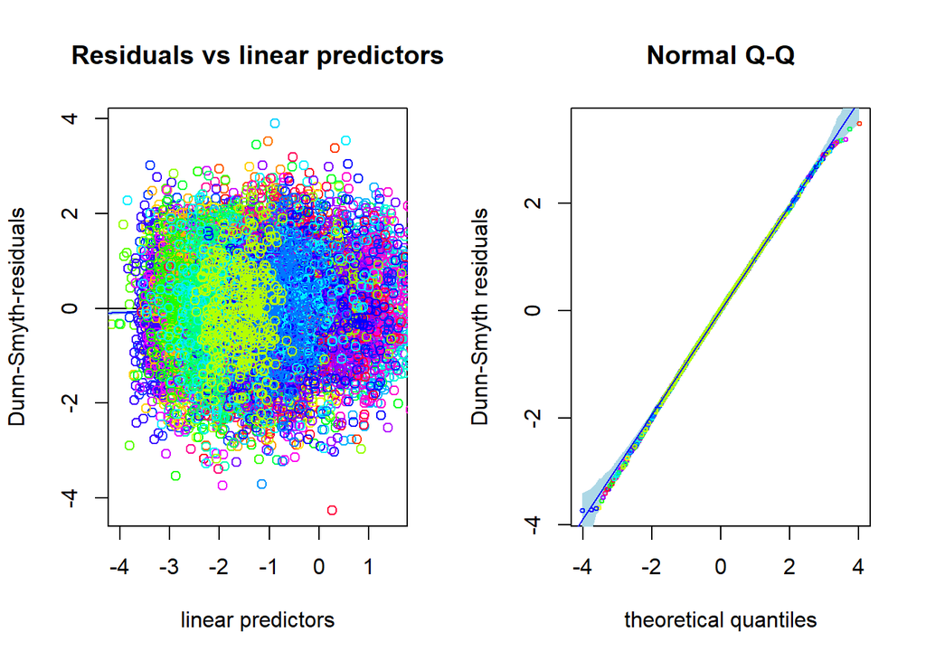

```r
#Model based ordination

library(mvabund)
library(gllvm)

y <- as.matrix(df_list$macroinv)
x <- scale(as.matrix(df_list$env))
TR <-df_list$traits


fit_bin <- gllvm(y, family="binomial", method = "VA",link = "probit")

##plotting residuals for the Binomial model
par(mfrow = c(1,2))
plot(fit_bin, which = 1)
plot(fit_bin, which = 2)
```

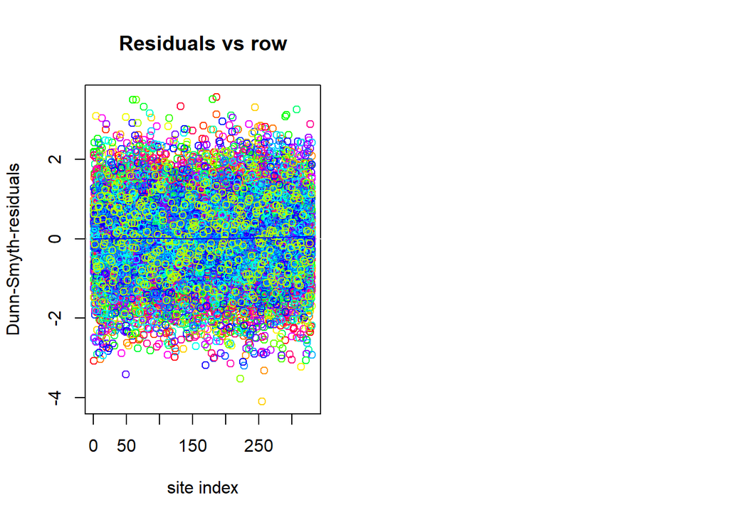

```r
plot(fit_bin, which = 3) #information criteria suggests binomial as good fit
```

Using ordiplot() function to construct an ordination as a scatter plot of predicted latent variables.

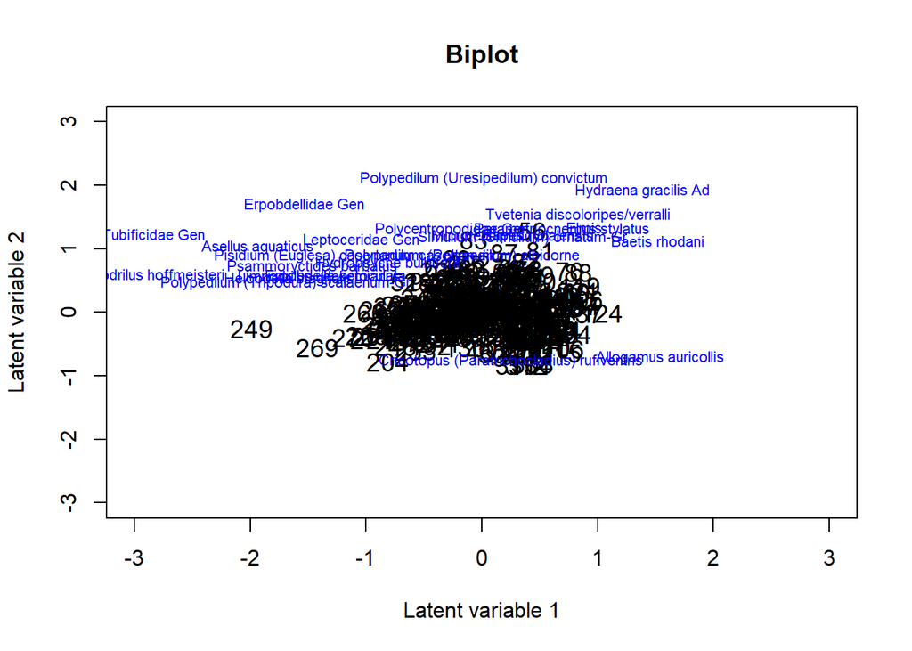

```r
ordiplot.gllvm(fit_bin, biplot = TRUE,ind.spp= 25, xlim = c(-3, 3), ylim = c(-3, 3), arrow.scale = 0.8,
         main = "Biplot")
```

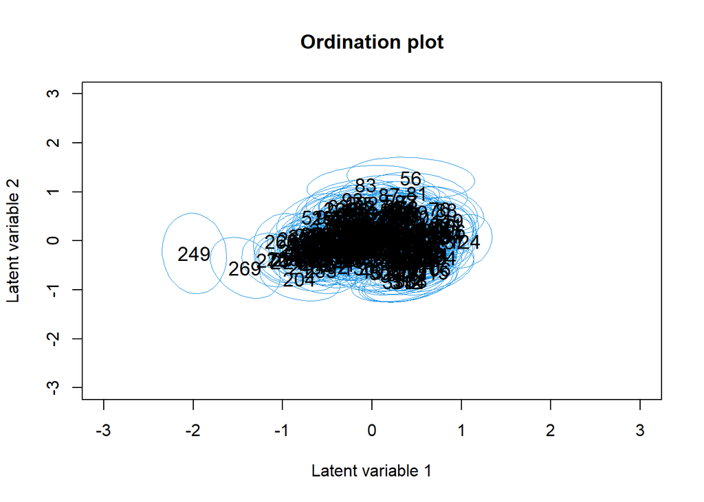

```r
ordiplot.gllvm(fit_bin, biplot = FALSE, ind.spp = 25, xlim = c(-3, 3), ylim = c(-3, 3),
         main = "Ordination plot", predict.region = TRUE)
```

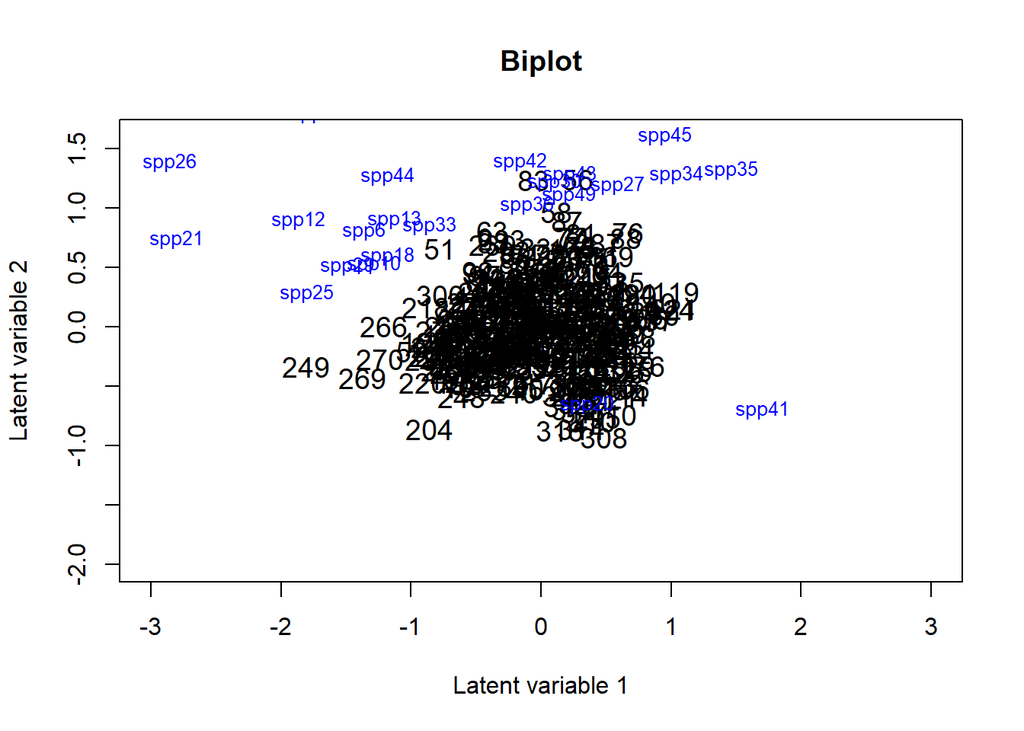

```r
rownames(fit_bin$params$theta) <- paste("spp", 1:ncol(fit_bin$y), sep = "") #replacing long species name with shorter one.
ordiplot.gllvm(fit_bin, biplot = TRUE, ind.spp = 25, xlim = c(-3, 3), ylim = c(-2, 1.6),
         main = "Biplot", jitter = TRUE, cex.spp = 0.8)
```

The graph shows larger cluster of sites in the center with very few indicator species whereas most indicator species are seen in the further side from larger cluster of sites.

#Modelling with environment variable Using residual analysis and information criteria to study which distribution offers the most suitable mean-variance relationship for the responses, and how many latent variables are needed.

```r
criterias <- NULL
for(i in 0:5){
  fiti <- gllvm(y, x, family = "binomial", num.lv = i, sd.errors = FALSE,
                formula = ~ temperature + conductivity+ altitude, seed = 1234)
  criterias[i + 1] <- summary(fiti)$AICc
  names(criterias)[i + 1] = i
}

criterias
```

```
##        0        1        2        3        4        5
## 11642.72 11488.22 11444.42 11544.32 11642.67 11739.51
```

Based on AICc values, 2 Latent variables was chosen

```r
#gllvm with environmental variables
fit_bin_env <- gllvm(y, x,
                     formula = ~ temperature + conductivity+ altitude,
                     family="binomial")

AIC(fit_bin_env)
```

```
## [1] 11433.35
```

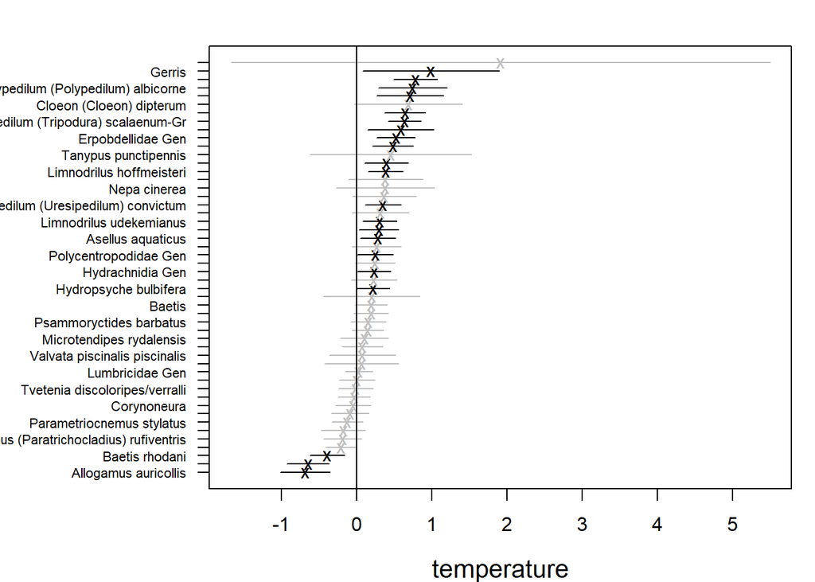

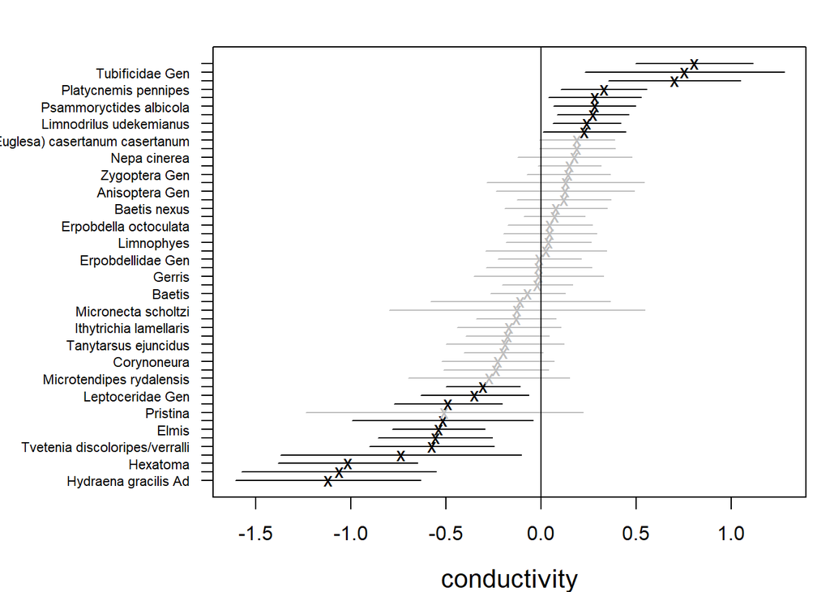

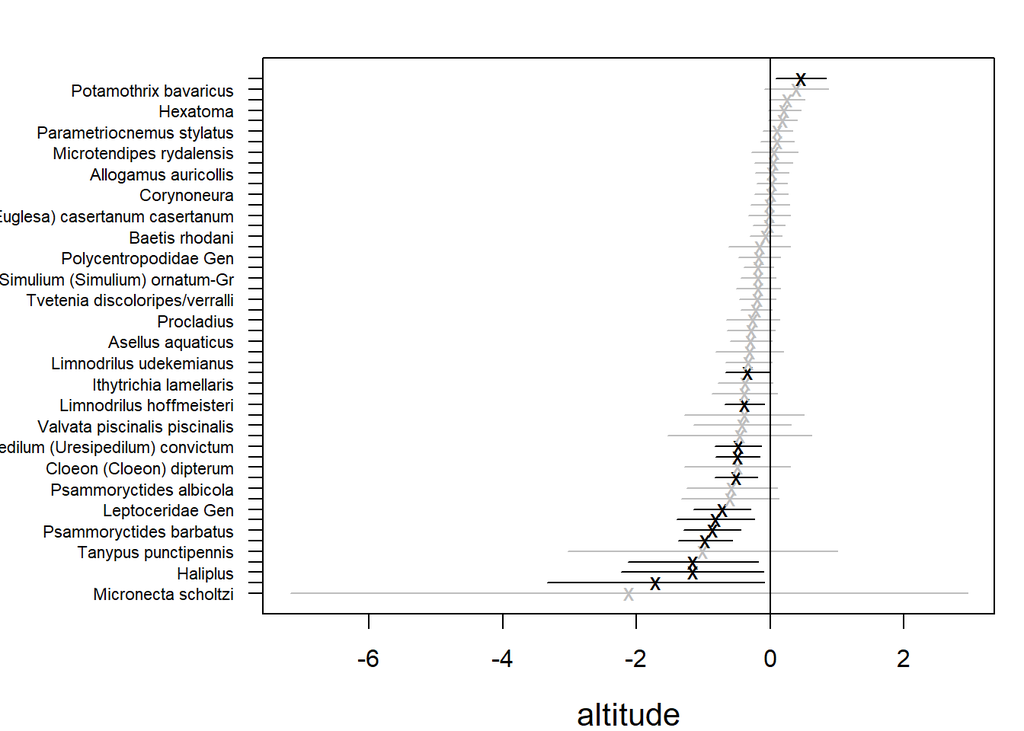

```r
#coefplot plots
coefplot(fit_bin_env, cex.ylab = 0.7, mar = c(4, 9, 2, 1),
         xlim.list = NULL, mfrow=c(1,1))
```

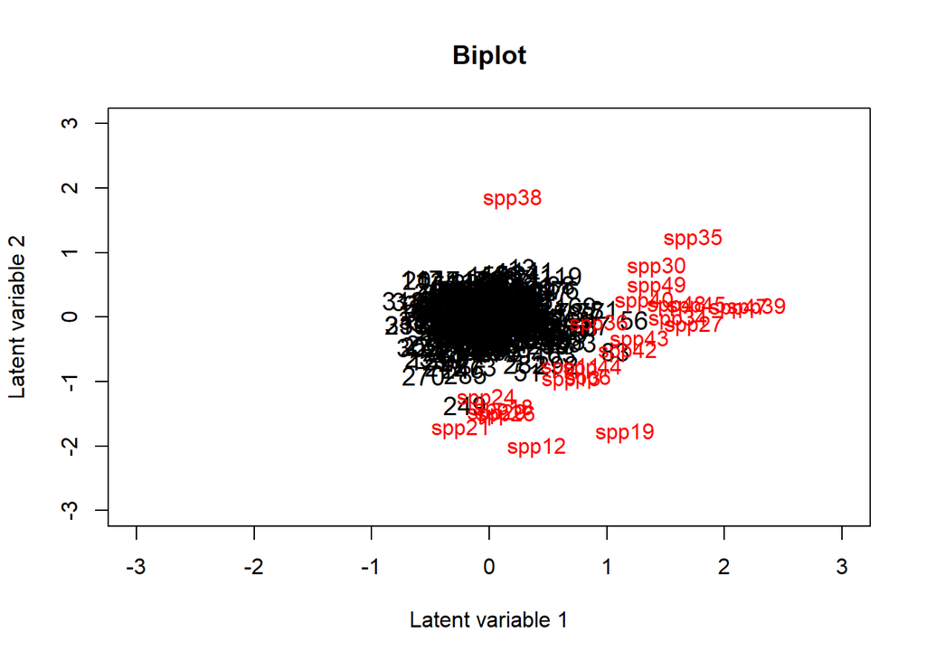

```r
#ordiplot
rownames(fit_bin_env$params$theta) <- paste("spp", 1:ncol(fit_bin_env$y), sep = "")

ordiplot.gllvm(fit_bin_env, biplot = TRUE,ind.spp= 25, xlim = c(-3, 3), ylim = c(-3, 3),
               spp.colors= "red", s.colors="black", cex.env= 0.007, cex.spp= 1,
             main = "Biplot")
```

In biplots we can see that Species 27 (Parametriocnemus stylatus), 43 (Microtendipes rydalensis), 45 (Tvetenia verralli) and 48(Sericostoma flavicorne) are close to each other. This can also be seen in the correlation plots as species correlations are positive.

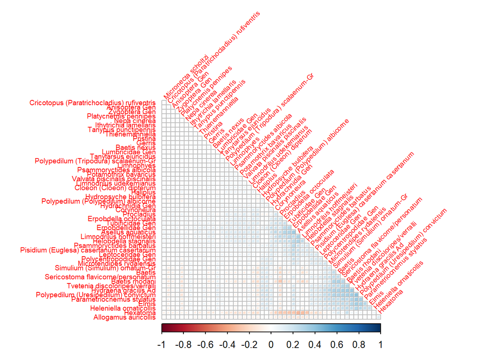

```r
# Residual correlation matrix (using getResidulaCOr() to estimate correlation matrix of linear predictor across species)
cr <- getResidualCor(fit_bin_env)
library(corrplot); library(gclus)
corrplot(cr[order.single(cr), order.single(cr)], diag = FALSE, type = "lower",
         method = "square", tl.cex = 0.6, tl.srt = 45, tl.col = "red")
```